# ChrisEscobedo_A3

Chris

February 18, 2022

## Introduction

This analysis will focus on the zip code area of 94804, which is in the South of Richmond. This area is intersting to analyze, as it has much lower median income and is much more diverse than many of the surrounding. This might imply that more of the members of this community will commute to work, as they are not able to afford areas closer to economic opportunities. It also will be interesting to look at the energy usage, given homes and buildings may be older and not as likely to be retrofitted because of the lack of capital for such upgrades. This context might provide valuable insight into how funding and support for upgrades in communities like this and affordable housing upgrades closer to job hubs could make large differences for reaching our GHG and equity goals as a state.

## Vehicle Emissions Analysis

To create the analysis of vehicle emissions, this report uses data from LODES for trip data. It uses data from 2013 to 2019 to calculate commute emissions for the zip code area in the south of Richmond as an origin and as a destination.

*This analysis assumes that commute data originating and ending in the same census block would be negligible, especially when compared to trips crossing boundaries of census block boundaries. Because this analysis groups trip origin and destination points by census block, the commute data that is within a single census block is disregarded and treated as zero. Of course, this will remove a non-zero number of trips and emissions from the final analysis. The assumption is that this omission will not likely constitute a large enough amount of emissions that the advantages of grouping by the census block to simplify the analysis will outweigh the disadvantages.*

Below is a map of the zip code area that will be used for this analysis.

[interactive chart not shown]

### Greenhouse Gas Emissions

Next we will use data from California Air Resources Board (CARB) Emission Factors (EMFAC) model to estimate the carbon emissions from these work trips from or to the South of Richmond. This model includes emissions rates data, year by year.

The annual amount of greenhouse gas emissions for vehicles entering or leaving the South Richmond zip code area from 20139-2019 is displayed below, in metric tonnes of CO2. It does show a slight, but steady decrease in greenhouse gas emissions from vehicles in the region.

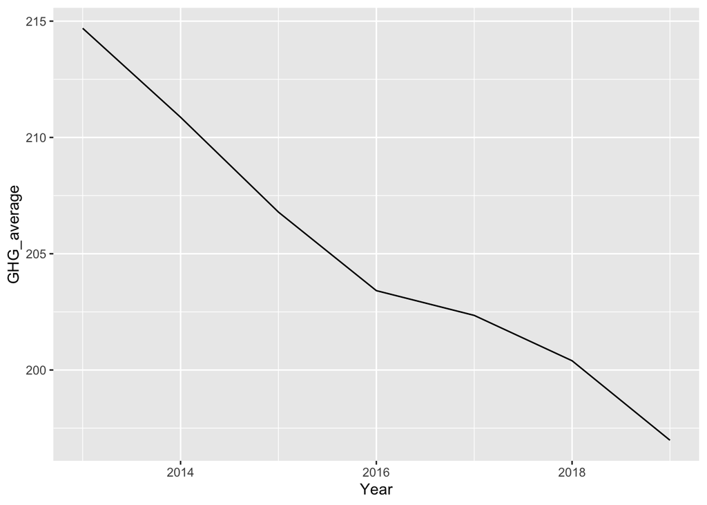

## Building Emissions Analysis

Next, we will conduct an analysis of building emissions for the same area, using PG&E electricity and gas data for the range of 2013 to 2019.

### Plot of Building Emissions

Below is a graph of the total annual amount of KBTU. The total amounts were estimated from the PG&E data, and normalized using population, jobs, and CDDs and HDDs.

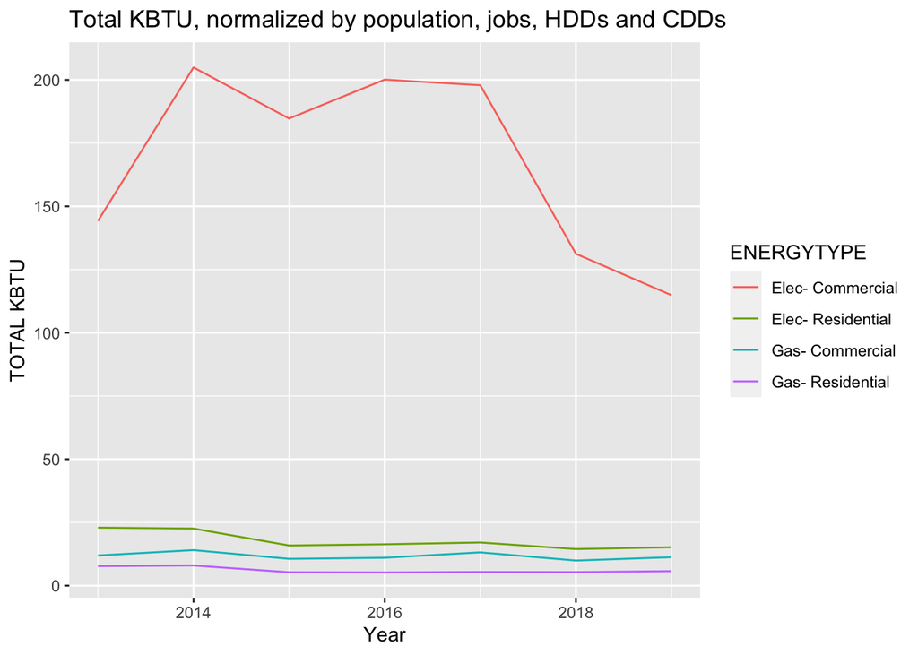

This plot demonstrates just how disproportionate electricity use is when compared to residential use, as well as gas usage for both residential and commercial use. This might imply that there is an industry that is using a large amount of electricity, specifically per the number of jobs it is producing. This implies an electricity heavy industry in the region that does not create a proportional amount of jobs for its electricity use.

### Graph of total Greenhouse Gas Emissions

Below is a graph that shows the total annual greenhouse gas emission for buildings and vehicles for the zip code area in the South of Richmond. It shows these amounts from 2013 to 2019.

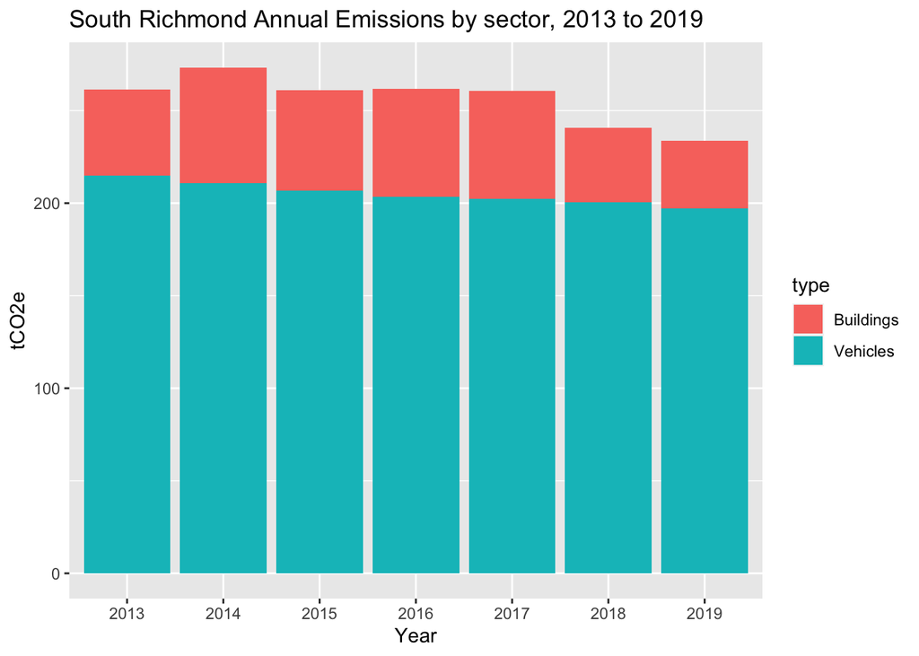

The graph clearly shows that the estimated greenhouse gas emissions from vehicles are much higher than that of buildings. The emissions of buildings have been normalized by population, jobs, and degree days of cooling and heating.

### Increasing Electric Vehicle trend

The graph below shows the emissions by car type and fuel type over the years. The graph shows zero emissions associated with electric vehicles, which is obviously not the whole picture, as it leaves out electricity generation.

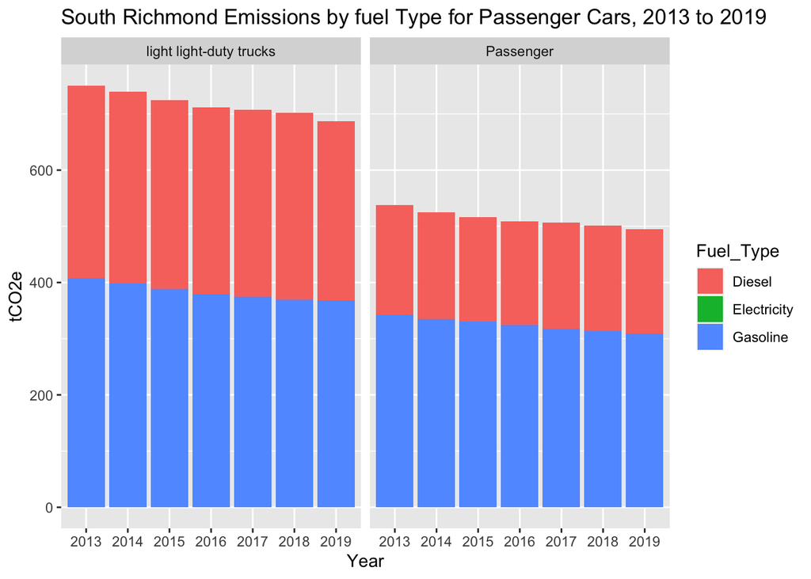

The graph above shows a gradual decrease in carbon emissions over the years, and also shows that light light-duty trucks have higher total emissions in the region.

The graph below shows the vehicle miles traveled associated with each vehicle type.

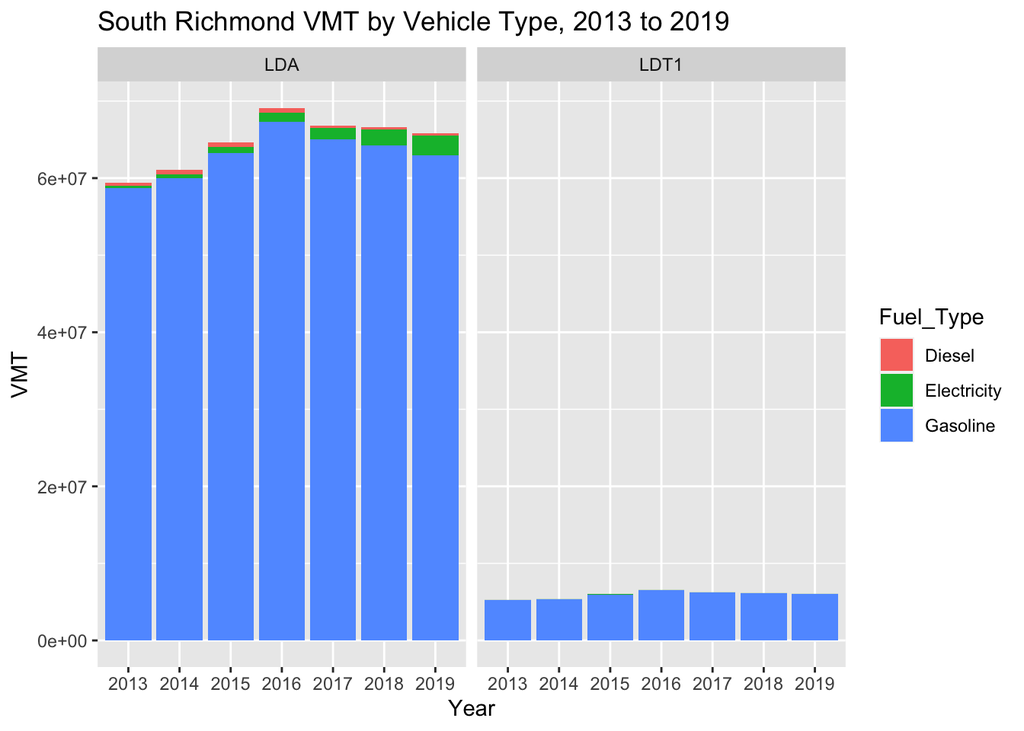

Interesting to note is that LDT1 (light light-duty trucks) have significantly less VMT, but more carbon emissions.

Another interesting trend is that although VMT is not decreasing by much, although it has slightly gone down after 2017, carbon emissions are still decreasing. This shows that although driving has not changed much, fuel type has had a notiecable impact on carbon emissions.

This likeley indicates a shift towards electric vehicles. This is a plan that the city is likely to pursue. Given how difficult is it to change driving patterns, changing the fuel type is a way to decrease carbon emissions immediately. Although, changing car stock comes with its own challenges and time delays.